# 摩拜单车数据集探索分析

## Preliminary Wrangling

> 数据集记录了上海地区摩拜单车的用户使用数据，包括单车编号、用户编号、骑行的起止时间等。

```python
# import all packages and set plots to be embedded inline
import numpy as np
import pandas as pd
import matplotlib.pyplot as plt
import seaborn as sb
import geopy.distance

%matplotlib inline
```

```python
data = pd.read_csv('../Mobike Data/mobike_shanghai_sample_updated.csv')
data.head()
```

|  | orderid | bikeid | userid | start_time | start_location_x | start_location_y | end_time | end_location_x | end_location_y | track |
| --- | --- | --- | --- | --- | --- | --- | --- | --- | --- | --- |
| 0 | 78387 | 158357 | 10080 | 2016-08-20 06:57 | 121.348 | 31.389 | 2016-08-20 07:04 | 121.357 | 31.388 | 121.347,31.392#121.348,31.389#121.349,31.390#1... |
| 1 | 891333 | 92776 | 6605 | 2016-08-29 19:09 | 121.508 | 31.279 | 2016-08-29 19:31 | 121.489 | 31.271 | 121.489,31.270#121.489,31.271#121.490,31.270#1... |
| 2 | 1106623 | 152045 | 8876 | 2016-08-13 16:17 | 121.383 | 31.254 | 2016-08-13 16:36 | 121.405 | 31.248 | 121.381,31.251#121.382,31.251#121.382,31.252#1... |
| 3 | 1389484 | 196259 | 10648 | 2016-08-23 21:34 | 121.484 | 31.320 | 2016-08-23 21:43 | 121.471 | 31.325 | 121.471,31.325#121.472,31.325#121.473,31.324#1... |
| 4 | 188537 | 78208 | 11735 | 2016-08-16 07:32 | 121.407 | 31.292 | 2016-08-16 07:41 | 121.418 | 31.288 | 121.407,31.291#121.407,31.292#121.408,31.291#1... |

```python
data.info()
data.describe()
```

```
<class 'pandas.core.frame.DataFrame'>
RangeIndex: 102361 entries, 0 to 102360
Data columns (total 10 columns):
orderid             102361 non-null int64
bikeid              102361 non-null int64
userid              102361 non-null int64
start_time          102361 non-null object
start_location_x    102361 non-null float64
start_location_y    102361 non-null float64
end_time            102361 non-null object
end_location_x      102361 non-null float64
end_location_y      102361 non-null float64
track               102361 non-null object
dtypes: float64(4), int64(3), object(3)
memory usage: 7.8+ MB
```

|  | orderid | bikeid | userid | start_location_x | start_location_y | end_location_x | end_location_y |
| --- | --- | --- | --- | --- | --- | --- | --- |
| count | 1.023610e+05 | 102361.000000 | 102361.000000 | 102361.000000 | 102361.000000 | 102361.000000 | 102361.000000 |
| mean | 8.940838e+05 | 155425.868690 | 7834.435644 | 121.454144 | 31.251740 | 121.453736 | 31.252029 |
| std | 5.219651e+05 | 98816.625402 | 4530.387938 | 0.060862 | 0.057358 | 0.061577 | 0.057740 |
| min | 6.000000e+00 | 3.000000 | 1.000000 | 121.173000 | 30.842000 | 120.486000 | 30.841000 |
| 25% | 4.386790e+05 | 74701.000000 | 4095.000000 | 121.415000 | 31.212000 | 121.414000 | 31.212000 |
| 50% | 8.901510e+05 | 141990.000000 | 7617.000000 | 121.456000 | 31.260000 | 121.456000 | 31.261000 |
| 75% | 1.343252e+06 | 228303.000000 | 11278.000000 | 121.497000 | 31.294000 | 121.497000 | 31.294000 |
| max | 1.807864e+06 | 387351.000000 | 17753.000000 | 121.970000 | 31.450000 | 121.971000 | 31.477000 |

### What is the structure of your dataset?

> 由订单号、自行车编号、用户编号、骑行开始时间、骑行开始的经纬度、骑行结束时间、骑行结束的经纬度及行经路线的经纬度等列组成。

### What is/are the main feature(s) of interest in your dataset?

> 骑行时间受到哪些变量的影响。

### What features in the dataset do you think will help support your investigation into your feature(s) of interest?

> 骑行时间受到骑行时是工作日/周末、开始骑行时间是几点、开始骑行位置及目的地位置的影响。

## 单变量探索 Univariate Exploration

```python
#修正 start_time 和 end_time 的数据类型
data.info()

data['start_time']= pd.to_datetime(data['start_time'])
data['end_time']= pd.to_datetime(data['end_time'])

data.info()
```

```
<class 'pandas.core.frame.DataFrame'>
RangeIndex: 102361 entries, 0 to 102360
Data columns (total 10 columns):
orderid             102361 non-null int64
bikeid              102361 non-null int64
userid              102361 non-null int64
start_time          102361 non-null object
start_location_x    102361 non-null float64
start_location_y    102361 non-null float64
end_time            102361 non-null object
end_location_x      102361 non-null float64
end_location_y      102361 non-null float64
track               102361 non-null object
dtypes: float64(4), int64(3), object(3)
memory usage: 7.8+ MB
<class 'pandas.core.frame.DataFrame'>
RangeIndex: 102361 entries, 0 to 102360
Data columns (total 10 columns):
orderid             102361 non-null int64
bikeid              102361 non-null int64
userid              102361 non-null int64
start_time          102361 non-null datetime64[ns]
start_location_x    102361 non-null float64
start_location_y    102361 non-null float64
end_time            102361 non-null datetime64[ns]
end_location_x      102361 non-null float64
end_location_y      102361 non-null float64
track               102361 non-null object
dtypes: datetime64[ns](2), float64(4), int64(3), object(1)
memory usage: 7.8+ MB
```

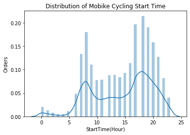

```python
#计算每天开始骑行的时间分布
start_time = data['start_time']
data['start_hour']= start_time.dt.hour

data.head()
base_color = sb.color_palette()[0]

sb.distplot(data['start_hour'],color=base_color)
plt.title("Distribution of Mobike Cycling Start Time")
plt.xlabel("StartTime(Hour)")
plt.ylabel("Orders")
```

- 观察结论：
  - 每天开始骑行的时间主要集中在早上7点至9点及晚上5点至9点的两个高峰时间。
  - 每天的时间低峰在23点到次日6点。
- 下一步调查计划： 观察工作日和周末开始骑行时间的分布图

### Discuss the distribution(s) of your variable(s) of interest. Were there any unusual points? Did you need to perform any transformations?

> 使用 data.describe() 检查数据集后未发现明显异常值； 使用直方图查看开始骑行时间的分布，工作日期间的骑行时间呈现明显双峰状，本次数据分析不特殊关注高峰期问题，因此不做转化。

### Of the features you investigated, were there any unusual distributions? Did you perform any operations on the data to tidy, adjust, or change the form of the data? If so, why did you do this?

> 1. 使用摩拜单车的骑行数据，使用 data.describe() 和 hist 分布图未查看到异常分布
> 2. 有改变 start_time 及 end_time 两列的数据类型便于后续的运算
>    - 原因：start_time 和 end_time 原来是 object 类型，无法直接使用 pandas 时间相关的函数，如定位 weekday、进行时间的加减等

## 双变量探索 Bivariate Exploration

```python
# 赋值工作日和周末两种类型
data['day_number'] = start_time.dt.weekday

#生成新的列来分类工作日和周末
data['weekday'] = np.where(data['day_number'] < 5,"weekday","weekend" )

#查看数据集是否正常
data.head()
data.info()
```

```
<class 'pandas.core.frame.DataFrame'>
RangeIndex: 102361 entries, 0 to 102360
Data columns (total 13 columns):
orderid             102361 non-null int64
bikeid              102361 non-null int64
userid              102361 non-null int64
start_time          102361 non-null datetime64[ns]
start_location_x    102361 non-null float64
start_location_y    102361 non-null float64
end_time            102361 non-null datetime64[ns]
end_location_x      102361 non-null float64
end_location_y      102361 non-null float64
track               102361 non-null object
start_hour          102361 non-null int64
day_number          102361 non-null int64
weekday             102361 non-null object
dtypes: datetime64[ns](2), float64(4), int64(5), object(2)
memory usage: 10.2+ MB
```

```python
#从 data.info 中判断 weekday 列应作为分类数据类型
data.weekday = data.weekday.astype('category')

#确认是否修改变类型成功
data.info()
```

```
<class 'pandas.core.frame.DataFrame'>
RangeIndex: 102361 entries, 0 to 102360
Data columns (total 13 columns):
orderid             102361 non-null int64
bikeid              102361 non-null int64
userid              102361 non-null int64
start_time          102361 non-null datetime64[ns]
start_location_x    102361 non-null float64
start_location_y    102361 non-null float64
end_time            102361 non-null datetime64[ns]
end_location_x      102361 non-null float64
end_location_y      102361 non-null float64
track               102361 non-null object
start_hour          102361 non-null int64
day_number          102361 non-null int64
weekday             102361 non-null category
dtypes: category(1), datetime64[ns](2), float64(4), int64(5), object(1)
memory usage: 9.5+ MB
```

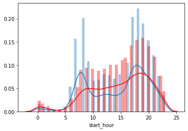

```python
#工作日和周末开始骑行时间的对比
sb.distplot(data.query('weekday=="weekday"')['start_hour'],color=base_color)
sb.distplot(data.query('weekday=="weekend"')['start_hour'],color='red')
```

- 观察结论：
  - 工作日的开始骑行时间在上下班高峰期明显
  - 周末的开始骑行时间相对平缓，在10点到18点间同样有大量订单分布

|  | orderid | bikeid | userid | start_location_x | start_location_y | end_location_x | end_location_y | start_hour | day_number | time |
| --- | --- | --- | --- | --- | --- | --- | --- | --- | --- | --- |
| count | 1.023610e+05 | 102361.000000 | 102361.000000 | 102361.000000 | 102361.000000 | 102361.000000 | 102361.000000 | 102361.000000 | 102361.000000 | 102361.000000 |
| mean | 8.940838e+05 | 155425.868690 | 7834.435644 | 121.454144 | 31.251740 | 121.453736 | 31.252029 | 14.489190 | 2.794502 | 17.026348 |
| std | 5.219651e+05 | 98816.625402 | 4530.387938 | 0.060862 | 0.057358 | 0.061577 | 0.057740 | 5.302643 | 1.996931 | 23.436665 |
| min | 6.000000e+00 | 3.000000 | 1.000000 | 121.173000 | 30.842000 | 120.486000 | 30.841000 | 0.000000 | 0.000000 | 1.000000 |
| 25% | 4.386790e+05 | 74701.000000 | 4095.000000 | 121.415000 | 31.212000 | 121.414000 | 31.212000 | 10.000000 | 1.000000 | 7.000000 |
| 50% | 8.901510e+05 | 141990.000000 | 7617.000000 | 121.456000 | 31.260000 | 121.456000 | 31.261000 | 16.000000 | 3.000000 | 12.000000 |
| 75% | 1.343252e+06 | 228303.000000 | 11278.000000 | 121.497000 | 31.294000 | 121.497000 | 31.294000 | 19.000000 | 5.000000 | 20.000000 |
| max | 1.807864e+06 | 387351.000000 | 17753.000000 | 121.970000 | 31.450000 | 121.971000 | 31.477000 | 23.000000 | 6.000000 | 1408.000000 |

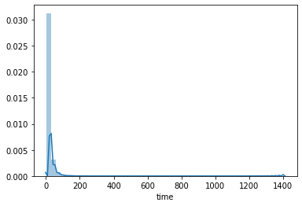

```python
#计算骑行时间
data['time'] = data['end_time'] - data['start_time']

#将骑行时间处理为分钟
data['time'] = data['time'].dt.components.minutes + data['time'].dt.components.hours * 60

#骑行分钟的直方图分布及数据集检查
sb.distplot(data['time'])
data.describe()
```

- 观察结论：
  - 直方图分布集中在 200 分钟以内，存在异常值需要进行处理
  - 根据 data.describe() 观察得知 time 的第三四分位数在 20，但最大值在 1408，存在异常值需要处理
- 下一步计划：进一步定位异常值，并对异常值进行处理

|  | orderid | bikeid | userid | start_location_x | start_location_y | end_location_x | end_location_y | start_hour | day_number | time |
| --- | --- | --- | --- | --- | --- | --- | --- | --- | --- | --- |
| count | 1.013340e+05 | 101334.000000 | 101334.000000 | 101334.000000 | 101334.000000 | 101334.000000 | 101334.000000 | 101334.000000 | 101334.000000 | 101334.000000 |
| mean | 8.928822e+05 | 155132.799584 | 7830.340922 | 121.454123 | 31.251887 | 121.453737 | 31.252186 | 14.472290 | 2.791768 | 15.643565 |
| std | 5.218460e+05 | 98705.591589 | 4529.363772 | 0.060843 | 0.057344 | 0.061432 | 0.057674 | 5.300002 | 1.995750 | 13.046853 |
| min | 6.000000e+00 | 3.000000 | 1.000000 | 121.173000 | 30.842000 | 120.486000 | 30.841000 | 0.000000 | 0.000000 | 1.000000 |
| 25% | 4.372745e+05 | 74463.500000 | 4093.000000 | 121.415000 | 31.212000 | 121.414000 | 31.212000 | 10.000000 | 1.000000 | 7.000000 |
| 50% | 8.887050e+05 | 141644.500000 | 7613.000000 | 121.456000 | 31.260000 | 121.456000 | 31.261000 | 16.000000 | 3.000000 | 11.000000 |
| 75% | 1.341312e+06 | 227840.500000 | 11273.000000 | 121.497000 | 31.294000 | 121.497000 | 31.294000 | 19.000000 | 5.000000 | 20.000000 |
| max | 1.807864e+06 | 387351.000000 | 17753.000000 | 121.970000 | 31.450000 | 121.971000 | 31.477000 | 23.000000 | 6.000000 | 87.000000 |

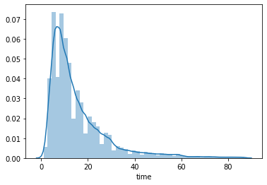

```python
#检查 time 的数据分布
q = data['time'].quantile(0.99)
#print(q)
new_data = data[data['time']<q]

#再次观察骑行时间的分布
sb.distplot(new_data['time'])
new_data.describe()
```

- 观察结论：骑行时长主要其中在 10 分钟左右
- 下一步计划：观察骑行时长与开始骑行时间是否有关系

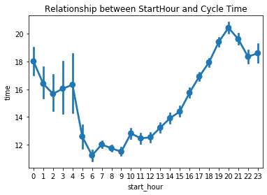

```python
# 观察开始骑行时间与骑行时长的关系
sb.pointplot(data=new_data,x="start_hour", y="time",color=base_color)

plt.title("Relationship between StartHour and Cycle Time")

plt.show()
```

- 观察结论：
  - 白天开始骑行时间在 6点-12点时，骑行时间相对较短，集中在15分钟以内；
  - 从中午12点后随着开始骑行时间的推迟，骑行时间明显增加；
  - 晚间 0点-4点 的骑行时长波动较大
- 下一步计划：
  - 观察工作日和周末的骑行时长是否有区别

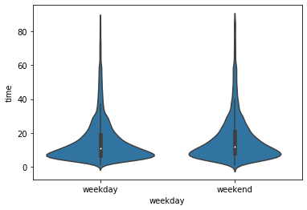

```python
#进一步分析工作日和周末的骑行时长分布是否有区别
sb.violinplot(data=new_data,
              x='weekday',y='time',
              order=['weekday','weekend'],
              color=base_color)

plt.show()
```

- 结论：
  - 观察到工作日的骑行时间主要集中在10分钟左右；
  - 周末的骑行时间主要也集中在10分钟以下，相对工作日来说更平滑，推测骑行时间受到是否是工作日(weekday)的影响。
- 下一步计划：在多变量分析中观察骑行时长与工作日/周末开始骑行时间的关系

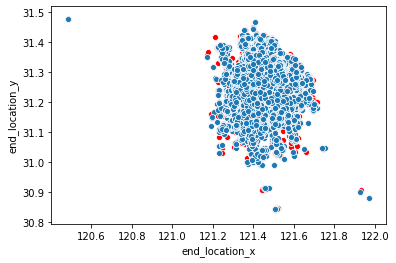

```python
#观察开始骑行位置和结束位置的分布图

sb.scatterplot(data = new_data,
               x="start_location_x",y="start_location_y",
               color="red")

sb.scatterplot(data = new_data,
               x="end_location_x",y="end_location_y",
               color= base_color)
```

- 观察结论：
  - 观察到部分异常值，分别位于散点图的左上角和下方
- 下一步计划：
  - 去除异常值

|  | orderid | bikeid | userid | start_location_x | start_location_y | end_location_x | end_location_y | start_hour | day_number | time |
| --- | --- | --- | --- | --- | --- | --- | --- | --- | --- | --- |
| count | 1.013340e+05 | 101334.000000 | 101334.000000 | 101334.000000 | 101334.000000 | 101334.000000 | 101334.000000 | 101334.000000 | 101334.000000 | 101334.000000 |
| mean | 8.928822e+05 | 155132.799584 | 7830.340922 | 121.454123 | 31.251887 | 121.453737 | 31.252186 | 14.472290 | 2.791768 | 15.643565 |
| std | 5.218460e+05 | 98705.591589 | 4529.363772 | 0.060843 | 0.057344 | 0.061432 | 0.057674 | 5.300002 | 1.995750 | 13.046853 |
| min | 6.000000e+00 | 3.000000 | 1.000000 | 121.173000 | 30.842000 | 120.486000 | 30.841000 | 0.000000 | 0.000000 | 1.000000 |
| 25% | 4.372745e+05 | 74463.500000 | 4093.000000 | 121.415000 | 31.212000 | 121.414000 | 31.212000 | 10.000000 | 1.000000 | 7.000000 |
| 50% | 8.887050e+05 | 141644.500000 | 7613.000000 | 121.456000 | 31.260000 | 121.456000 | 31.261000 | 16.000000 | 3.000000 | 11.000000 |
| 75% | 1.341312e+06 | 227840.500000 | 11273.000000 | 121.497000 | 31.294000 | 121.497000 | 31.294000 | 19.000000 | 5.000000 | 20.000000 |
| max | 1.807864e+06 | 387351.000000 | 17753.000000 | 121.970000 | 31.450000 | 121.971000 | 31.477000 | 23.000000 | 6.000000 | 87.000000 |

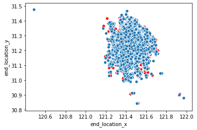

```python
#定义去除异常值的方法
def exclude_outlier(df, column):
    q_low = df[column].quantile(0.01)
    q_high = df[column].quantile(0.99)

    new_data_1 = df[(df[column]<q_high) & df[column]>q_low]

    #print(new_data_1.info())
    return new_data_1

exclude_outlier(new_data,'start_location_x')
exclude_outlier(new_data,'start_location_y')
exclude_outlier(new_data,'end_location_x')
exclude_outlier(new_data,'end_location_y')
new_data_1=new_data

#再次观察开始骑行位置和结束骑行位置的分布
sb.scatterplot(data = new_data_1,
               x="start_location_x",y="start_location_y",
               color="red")

sb.scatterplot(data = new_data_1,
               x="end_location_x",y="end_location_y",
               color= base_color)

new_data_1.describe()
```

```
<class 'pandas.core.frame.DataFrame'>
Int64Index: 2000 entries, 51072 to 48353
Data columns (total 14 columns):
orderid             1972 non-null float64
bikeid              1972 non-null float64
userid              1972 non-null float64
start_time          1972 non-null datetime64[ns]
start_location_x    1972 non-null float64
start_location_y    1972 non-null float64
end_time            1972 non-null datetime64[ns]
end_location_x      1972 non-null float64
end_location_y      1972 non-null float64
track               1972 non-null object
start_hour          1972 non-null float64
day_number          1972 non-null float64
weekday             1972 non-null category
time                1972 non-null float64
dtypes: category(1), datetime64[ns](2), float64(10), object(1)
memory usage: 220.8+ KB
```

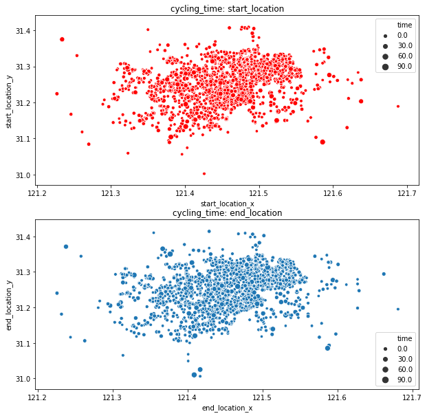

```python
samples = np.random.choice(new_data_1.shape[0], 2000, replace = False)
data_sample = new_data_1.loc[samples,:]

data_sample.describe()
data_sample.info()

fig, (ax2,ax) = plt.subplots(nrows=2,figsize=(10,10))

ax2.set_title('cycling_time: start_location')
sb.scatterplot(data = data_sample,
                x="start_location_x",y="start_location_y",
               color="red",size='time',ax = ax2)


ax.set_title('cycling_time: end_location')
sb.scatterplot(data = data_sample,
               x="end_location_x",y="end_location_y",
               color= base_color,size='time',ax=ax)
```

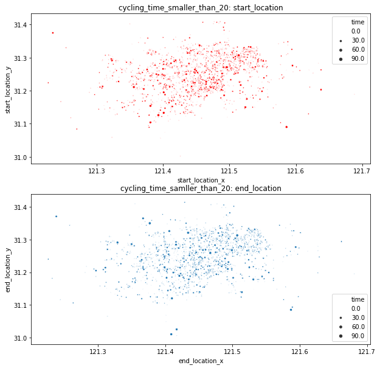

```python
#抽查验证骑行时间小于20分钟（长于60分钟）的分布
fig, (ax3,ax4) = plt.subplots(nrows=2,figsize=(10,10))

ax3.set_title('cycling_time_smaller_than_20: start_location')
sb.scatterplot(data = data_sample,
                x="start_location_x",y="start_location_y",
               color="red",size='time',ax = ax3, sizes=(0,20))
                #color="red",size='time',ax = ax3, sizes=(60,90))



ax4.set_title('cycling_time_samller_than_20: end_location')
sb.scatterplot(data = data_sample,
               x="end_location_x",y="end_location_y",
               color= base_color,size='time',ax=ax4, sizes=(0,20))
                #color=base_color,size='time',ax = ax3, sizes=(60,90))
```

- 观察结论：圆圈的大小（骑行时间的长短）和位置没有直接关系，即开始骑行位置和结束骑行位置和骑行时间无明显的相关性
- 下一步：计算开始骑行位置与结束骑行位置间的距离

```python
import math

new_data_2 = new_data_1


def haversine_vectorize(lon1, lat1, lon2, lat2):

    lon1, lat1, lon2, lat2 = map(np.radians, [lon1, lat1, lon2, lat2])

    newlon = lon2 - lon1
    newlat = lat2 - lat1

    haver_formula = np.sin(newlat/2.0)**2 + np.cos(lat1) * np.cos(lat2) * np.sin(newlon/2.0)**2

    dist = 2 * np.arcsin(np.sqrt(haver_formula ))
    km = 6367 * dist
    return km

new_data_2['distance'] = haversine_vectorize(new_data_2['start_location_x'],new_data_2['start_location_y'],new_data_2['end_location_x'],new_data_2['end_location_y'])

new_data_2.describe()
```

|  | orderid | bikeid | userid | start_location_x | start_location_y | end_location_x | end_location_y | start_hour | day_number | time | distance |
| --- | --- | --- | --- | --- | --- | --- | --- | --- | --- | --- | --- |
| count | 1.013340e+05 | 101334.000000 | 101334.000000 | 101334.000000 | 101334.000000 | 101334.000000 | 101334.000000 | 101334.000000 | 101334.000000 | 101334.000000 | 101334.000000 |
| mean | 8.928822e+05 | 155132.799584 | 7830.340922 | 121.454123 | 31.251887 | 121.453737 | 31.252186 | 14.472290 | 2.791768 | 15.643565 | 1.535269 |
| std | 5.218460e+05 | 98705.591589 | 4529.363772 | 0.060843 | 0.057344 | 0.061432 | 0.057674 | 5.300002 | 1.995750 | 13.046853 | 1.416905 |
| min | 6.000000e+00 | 3.000000 | 1.000000 | 121.173000 | 30.842000 | 120.486000 | 30.841000 | 0.000000 | 0.000000 | 1.000000 | 0.146093 |
| 25% | 4.372745e+05 | 74463.500000 | 4093.000000 | 121.415000 | 31.212000 | 121.414000 | 31.212000 | 10.000000 | 1.000000 | 7.000000 | 0.722938 |
| 50% | 8.887050e+05 | 141644.500000 | 7613.000000 | 121.456000 | 31.260000 | 121.456000 | 31.261000 | 16.000000 | 3.000000 | 11.000000 | 1.127370 |
| 75% | 1.341312e+06 | 227840.500000 | 11273.000000 | 121.497000 | 31.294000 | 121.497000 | 31.294000 | 19.000000 | 5.000000 | 20.000000 | 1.873389 |
| max | 1.807864e+06 | 387351.000000 | 17753.000000 | 121.970000 | 31.450000 | 121.971000 | 31.477000 | 23.000000 | 6.000000 | 87.000000 | 93.149194 |

- 观察结论：骑行距离（distance）列中可能存在异常值，75% 分位数为 1.87，但最大值是 93.14，偏差过大
- 下一步计划：定位异常值并去除异常值

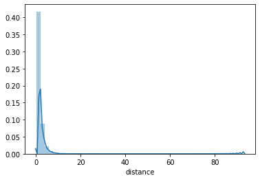

```python
sb.distplot(new_data_2['distance'])

q = new_data_2['distance'].quantile(0.99)
mobike_data = new_data_2[new_data_2['distance']<q]
```

- 观察结论：骑行距离集中在 1 km左右的距离，为了避免异常值影响，去除原数据集中 99% 分位数后的数据
- 下一步计划：观察新数据集是否正常

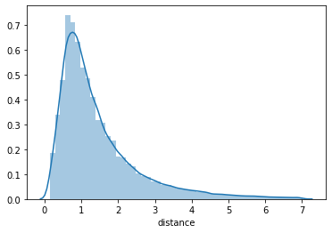

```python
sb.distplot(mobike_data['distance'])
```

- 观察结论：骑行距离（distance）呈右偏分布，集中在 1 km左右
- 下一步计划：观察骑行距离(distance)和骑行时间(time)的是否存在线性回归关系

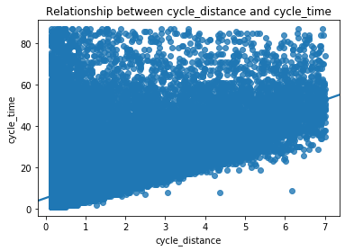

```python
#观察骑行距离与骑行时间的关系
sb.regplot(x="distance",y="time",data=mobike_data)

plt.xlabel("cycle_distance")
plt.ylabel("cycle_time")
plt.title("Relationship between cycle_distance and cycle_time")
```

- 观察结论：
  - 骑行距离和骑行时间存在部分相关性，主要体现在骑行距离超过一定距离后，骑行时间大于特定值，如骑行在5km以上，骑行时间超过20分钟
  - 但可能也会出现骑行距离少，但骑行时间长的情况。
- 下一步计划：在多变量探索中引入是否为工作日（weekday）的变量，观察多变量间的关系

### Talk about some of the relationships you observed in this part of the investigation. How did the feature(s) of interest vary with other features in the dataset?

> 骑行时长与开始骑行时间有明显的关系：开始骑行时间在6点-12点时，骑行时间相对较短，集中在13分钟以内；从中午12点-20点随着开始骑行时间的推迟，骑行时间明显增加，20点的骑行时长约为20分钟；晚间0点-4点的骑行时长波动较大。

> 骑行距离和骑行时间存在部分相关性，主要体现在骑行距离超过一定距离后，骑行时间大于特定值，如骑行在5km以上，骑行时间超过20分钟

### Did you observe any interesting relationships between the other features (not the main feature(s) of interest)?

> 最开始假设骑行时长与开始骑行位置和结束骑行位置有关系（例如从A地开始骑行，骑行时间会偏长），因此新增加了骑行距离作为变量列，观察到骑行时长和骑行距离有部分的相关性。

## 多变量探索 Multivariate Exploration

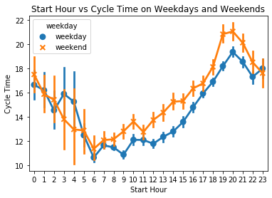

```python
sb.pointplot(data=mobike_data,x="start_hour", y="time",markers=["o", "x"],
           hue="weekday",hue_order=["weekday","weekend"])

plt.xlabel('Start Hour')
plt.ylabel('Cycle Time')
plt.title('Start Hour vs Cycle Time on Weekdays and Weekends')

plt.show()
```

- 结论：
  - 周末的开始骑行时间在上午9点到下午4点和晚上7点到10点间，显著超过工作日对应时段的平均骑行时间。
  - 因此推测骑行时间(time)作为因变量，受到 是否是工作日（weekday）和开始骑行时间(start_hour)两个自变量的影响 。

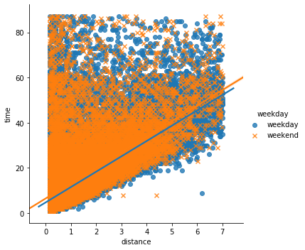

```python
#观察骑行距离与骑行时间的关系
sb.lmplot(x="distance",y="time",
          #col="weekday",
          hue="weekday",markers=["o", "x"],
          data=mobike_data)

plt.show()
```

- 观察结论：
  - 工作日更容易出现骑行距离长、骑行时间长的骑行情况；
  - 周末的骑行时间和骑行距离更集中在5km/40分钟以内。

### Talk about some of the relationships you observed in this part of the investigation. Were there features that strengthened each other in terms of looking at your feature(s) of interest?

> 在多变量分析中，除了原有的骑行时长与开始骑行时间、骑行距离的关系分析，引入了是否为工作日（weekday/weekend）的分类变量，从而观察到了骑行时长在工作日/周末的变动特点。

> 具体表现为：1) 周末的开始骑行时间在上午9点到下午4点和晚上7点到10点间，用户的骑行时长显著超过工作日对应时段的骑行时长; 2) 工作日更容易出现骑行距离长、骑行时间长的骑行情况；周末的骑行时间和骑行距离更集中在5km/40分钟以内。